# seguimiento v7

Hernan Nuñez

9/8/2020

### Objetivo del trabajo

La finalidad de este trabajo es encontrar relaciones entre las categorias de las variables cualitativas “organo de pertenencia” y “años trabajando para el estado”.

## Librerias

Paquetes usados para el R

```r
library(tidyverse)
library(readxl)
library(lubridate)
```

```r
library(ca)
library(gplots)
library(factoextra)
library(FactoMineR)
library(GGally)
library(knitr)
library(corrplot)
```

## Base de datos de la encuesta

Vista parcial de la base de datos de la encuesta

```r
bbdd <- read_excel("promsace 6agosto6pm.xlsx",
    sheet = "Base de datos", range = "A3:AA3997",
    col_types = c("date", "text", "text", "text",
        "text", "text", "text", "text", "text",
        "text", "text", "text", "text", "text",
        "text", "text", "text", "text", "text",
        "text", "text", "text", "text", "text",
        "text", "text", "text"))
#-------------------

bbdd$`Recursos humanos` <- factor(bbdd$`Recursos humanos`, levels = c("Recursos humanos (capacitación, selección de personal, liquidación de beneficios, control de asistencia, etc.)", "No Aplica", "Sin Respuesta"), labels = c("Si", "No", "Sin Respuesta"))

#-------------------

bbdd$Abastecimiento <- factor(bbdd$Abastecimiento, levels = c("Abastecimiento (contratación de proveedores, patrimonio, términos de referencia, etc.)", "No Aplica", "Sin Respuesta"), labels = c("Si", "No", "Sin Respuesta"))

#-------------------

bbdd$`Presupuesto público` <- factor(bbdd$`Presupuesto público`, levels = c("Presupuesto público (PIA, PIM, PPR, certificación, devengado, etc.)", "No Aplica", "Sin Respuesta"), labels = c("Si", "No", "Sin Respuesta"))

#-------------------

bbdd$Tesorería <- factor(bbdd$Tesorería, levels = c("Tesorería (viajes y viáticos, caja única, caja chica, etc.)", "No Aplica", "Sin Respuesta"), labels = c("Si", "No", "Sin Respuesta"))

#-------------------

bbdd$Contabilidad <- factor(bbdd$Contabilidad, levels = c("Contabilidad (rendición de cuentas, Cuenta General de la República, estados financieros, etc.)", "No Aplica", "Sin Respuesta"), labels = c("Si", "No", "Sin Respuesta"))

#-------------------

bbdd$Control <- factor(bbdd$Control, levels = c("Control (previo, simultáneo, concurrente, auditorías externas etc.)", "No Aplica", "Sin Respuesta"), labels = c("Si", "No", "Sin Respuesta"))

#-------------------

bbdd$`Inversión pública` <- factor(bbdd$`Inversión pública`, levels = c("Inversión pública (perfil, formulación, evaluación, expediente técnico, banco de inversiones, etc.)", "No Aplica", "Sin Respuesta"), labels = c("Si", "No", "Sin Respuesta"))

#-------------------

bbdd$`Planeamiento estratégico` <- factor(bbdd$`Planeamiento estratégico`, levels = c("Planeamiento estratégico (POI, PEI, PDC, PESEM)", "No Aplica", "Sin Respuesta"), labels = c("Si", "No", "Sin Respuesta"))

#-------------------

bbdd$`Modernización de la Gestión Pública` <- factor(bbdd$`Modernización de la Gestión Pública`, levels = c("Modernización de la Gestión Pública (estructura y funcionamiento, procedimientos administrativos, procesos, gobierno abierto, etc.)", "No Aplica", "Sin Respuesta"), labels = c("Si", "No", "Sin Respuesta"))

#-------------------

bbdd$`No sé` <- factor(bbdd$`No sé`, levels = c("No sé", "No Aplica", "Sin Respuesta"), labels = c("Si", "No", "Sin Respuesta"))

#-------------------

bbdd$Otro <- factor(bbdd$Otro,levels = c("Si", "No", "Sin Respuesta"))

#-------------------

bbdd$`Cambiar el marco normativo` <- factor(bbdd$`Cambiar el marco normativo`, levels = c("Cambiar el marco normativo", "No Aplica", "Sin Respuesta"), labels = c("Si", "No", "Sin Respuesta"))

#-------------------

bbdd$`Potenciar conocimientos y habilidades de los servidores civiles` <- factor(bbdd$`Potenciar conocimientos y habilidades de los servidores civiles`, levels = c("Potenciar conocimientos y habilidades de los servidores civiles", "No Aplica", "Sin Respuesta"), labels = c("Si", "No", "Sin Respuesta"))

#-------------------

bbdd$`Articular labores entre áreas` <- factor(bbdd$`Articular labores entre áreas`, levels = c("Articular labores entre áreas", "No Aplica", "Sin Respuesta"), labels = c("Si", "No", "Sin Respuesta"))

#-------------------

bbdd$`Mejorar los sistemas informáticos y sistematizar procesos` <- factor(bbdd$`Mejorar los sistemas informáticos y sistematizar procesos`, levels = c("Mejorar los sistemas informáticos y sistematizar procesos", "No Aplica", "Sin Respuesta"), labels = c("Si", "No", "Sin Respuesta"))

#-------------------

bbdd$`Mejorar la coordinación con el ente rector y otras instituciones` <- factor(bbdd$`Mejorar la coordinación con el ente rector y otras instituciones`, levels = c("Mejorar la coordinación con el ente rector y otras instituciones", "No Aplica", "Sin Respuesta"), labels = c("Si", "No", "Sin Respuesta"))

#-------------------

bbdd$lista <- factor(bbdd$lista, levels = c("254102633", "256377828", "262814520", "262814761", "262814235"), labels = c("Web Link 1", "Piloto", "Lista 2", "Lista 1", "Lista 3"))

#-------------------

bbdd$Identificado <- factor(bbdd$Identificado , levels = c("Identificado", "No Identificado", "Viciado", "No Aplica", "Sin Respuesta"))

#-------------------

bbdd$Priorizado <- factor(bbdd$Priorizado , levels = c("Si", "No", "Viciado", "No Aplica", "Sin Respuesta"))

#--------------------

bbdd$`Nivel de gobierno` <- factor(bbdd$`Nivel de gobierno` , levels = c("Nacional", "Regional", "Local", "Viciado", "No Identificado", "No Aplica", "Sin Respuesta"))

#-------------------

bbdd$`Organo de pertenencia` <- factor(bbdd$`Organo de pertenencia`, levels = c("Órgano de Apoyo (recursos humanos, administración, tecnologías de la información, otros)", "Órgano de Asesoría (jurídica, planeamiento, presupuesto, otros)", "Órgano de Línea", "Otros", "Sin Respuesta"), labels = c("apoyo", "asesoria", "linea", "Otros","Sin Respuesta"))

#--------------------

bbdd$Sexo <- factor(bbdd$Sexo , levels = c("Hombre", "Mujer", "Sin Respuesta"))

#-------------------

bbdd$`Años trabajando en el Estado` <- factor(bbdd$`Años trabajando en el Estado`, levels = c("Menos de dos años", "De dos a cinco años", "De seis a diez años", "Más de diez años", "Sin Respuesta"), labels = c("[0 - 2>", "[2 - 5]", "[6 - 10]", "[11 a más>", "Sin Respuesta"))

#-------------------

bbdd$año <- year(bbdd$Fecha)

#-------------------

bbdd$mes <- month(bbdd$Fecha)

#-------------------

bbdd$dia <- day(bbdd$Fecha)

#-------------------

bbdd$hora <- hour(bbdd$Fecha)

#-------------------

bbdd$minuto <- min(bbdd$Fecha)

#-------------------

bbdd$segundo <- second(bbdd$Fecha)

#-------------------

bbdd$dia_de_la_semana <- wday(bbdd$Fecha, label = TRUE)

#------------------

bbdd$semana <- week(bbdd$Fecha)

head(bbdd)
```

```
## # A tibble: 6 x 35
##   Fecha               lista `Traba administ~ `Recursos human~ Abastecimiento
##   <dttm>              <fct> <chr>            <fct>            <fct>
## 1 2020-02-28 10:16:04 Web ~ x                No               Si
## 2 2020-02-28 11:03:11 Web ~ Prueba           No               No
## 3 2020-02-28 11:29:31 Web ~ gbfghjhjhj       Sin Respuesta    Sin Respuesta
## 4 2020-02-28 12:01:00 Web ~ prueba GYA       No               Si
## 5 2020-02-28 13:41:09 Web ~ Que tengo que h~ No               No
## 6 2020-02-28 13:41:35 Web ~ Demora ( pago d~ No               No
## # ... with 30 more variables: `Presupuesto público` <fct>, Tesorería <fct>,
## #   Contabilidad <fct>, Control <fct>, `Inversión pública` <fct>, `Planeamiento
## #   estratégico` <fct>, `Modernización de la Gestión Pública` <fct>, `No
## #   sé` <fct>, Otro <fct>, `Cambiar el marco normativo` <fct>, `Potenciar
## #   conocimientos y habilidades de los servidores civiles` <fct>, `Articular
## #   labores entre áreas` <fct>, `Mejorar los sistemas informáticos y
## #   sistematizar procesos` <fct>, `Mejorar la coordinación con el ente rector y
## #   otras instituciones` <fct>, `Entidad publica` <chr>, Identificado <fct>,
## #   Priorizado <fct>, `Nivel de gobierno` <fct>, `Organo de pertenencia` <fct>,
## #   Sexo <fct>, `Años trabajando en el Estado` <fct>, completa <chr>,
## #   año <dbl>, mes <dbl>, dia <int>, hora <int>, minuto <dttm>, segundo <dbl>,
## #   dia_de_la_semana <ord>, semana <dbl>
```

## Formato de datos

Creamos la base de datos de dos variables: organo de pertenencia y años trabajando para el estado. Luego eliminamos las personas que no respondieron tales preguntas.

```r
bbdd2 <- bbdd %>%
  select(`Organo de pertenencia`, `Años trabajando en el Estado`) %>%
  filter(`Organo de pertenencia` != "Sin Respuesta")

#-------------------

bbdd2$`Organo de pertenencia` <- factor(bbdd2$`Organo de pertenencia`, levels = c("apoyo", "asesoria", "linea", "Otros"))

#-------------------

bbdd2$`Años trabajando en el Estado` <- factor(bbdd2$`Años trabajando en el Estado`, levels = c("[0 - 2>", "[2 - 5]", "[6 - 10]", "[11 a más>"))

bbdd2 <- data.frame(bbdd2$`Organo de pertenencia`, bbdd2$`Años trabajando en el Estado`)

names(bbdd2) <- c("Organo de pertenencia", "Años trabajando para el estado")

head(bbdd2)
```

```
##   Organo de pertenencia Años trabajando para el estado
## 1                 Otros                        [0 - 2>
## 2                 apoyo                        [0 - 2>
## 3              asesoria                        [2 - 5]
## 4                 Otros                        [0 - 2>
## 5              asesoria                     [11 a más>
## 6                 apoyo                       [6 - 10]
```

## Grafico de tabla de contingencia y test chi cuadrado

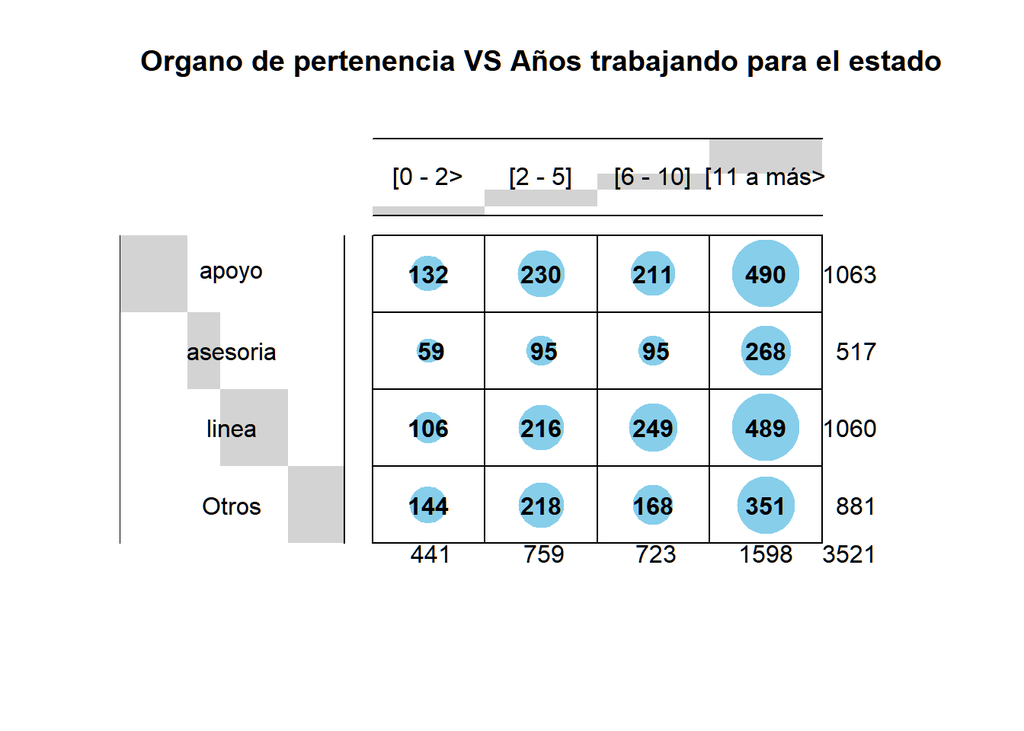

```r
dt <- table(bbdd2$`Organo de pertenencia`, bbdd2$`Años trabajando para el estado`)

balloonplot(t(dt), main = "Organo de pertenencia VS Años trabajando para el estado", xlab = "", ylab = "", label = TRUE, show.margins = TRUE)
```

Test chi cuadrado de independencia

```r
chisq <- chisq.test(dt)
chisq
```

```
##
##  Pearson's Chi-squared test
##
## data:  dt
## X-squared = 41.256, df = 9, p-value = 4.492e-06
```

Con un nivel de significancia del 5% vemos que no hay evidencia suficiente para decir que las dos variables son independientes.

## Componentes principales

```r
res.ca <- CA(dt, graph = FALSE)
print(res.ca)
```

```
## **Results of the Correspondence Analysis (CA)**
## The row variable has  4  categories; the column variable has 4 categories
## The chi square of independence between the two variables is equal to 41.25633 (p-value =  4.492211e-06 ).
## *The results are available in the following objects:
##
##    name              description
## 1  "$eig"            "eigenvalues"
## 2  "$col"            "results for the columns"
## 3  "$col$coord"      "coord. for the columns"
## 4  "$col$cos2"       "cos2 for the columns"
## 5  "$col$contrib"    "contributions of the columns"
## 6  "$row"            "results for the rows"
## 7  "$row$coord"      "coord. for the rows"
## 8  "$row$cos2"       "cos2 for the rows"
## 9  "$row$contrib"    "contributions of the rows"
## 10 "$call"           "summary called parameters"
## 11 "$call$marge.col" "weights of the columns"
## 12 "$call$marge.row" "weights of the rows"
```

## Autovalores/ Varianzas

Los autovalores determinan el numero de ejes a considerar. Consideran la cantidad de informacion retenida por cada eje.

```r
eig.val <- get_eigenvalue(res.ca)
eig.val
```

```
##         eigenvalue variance.percent cumulative.variance.percent
## Dim.1 9.267793e-03       79.0954936                    79.09549
## Dim.2 2.408259e-03       20.5531637                    99.64866
## Dim.3 4.116759e-05        0.3513427                   100.00000
```

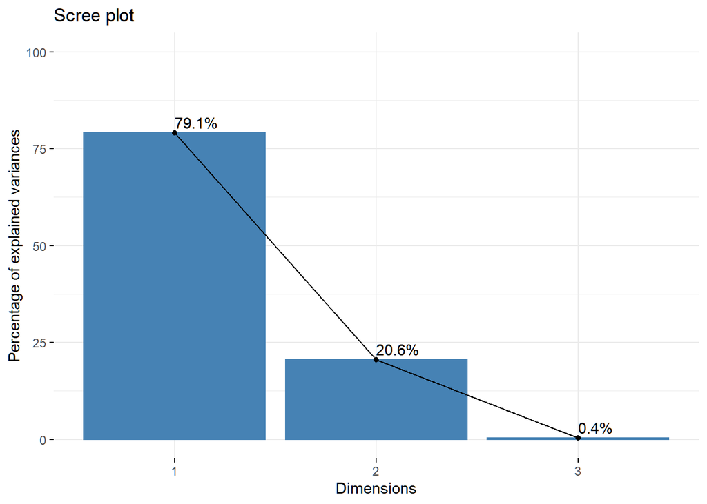

```r
fviz_screeplot(res.ca, addlabels = TRUE, ylim = c(0, 100))
```

El punto sobre la cual la linea toma una curvatura indica la dimensionalidad optima a tomar.

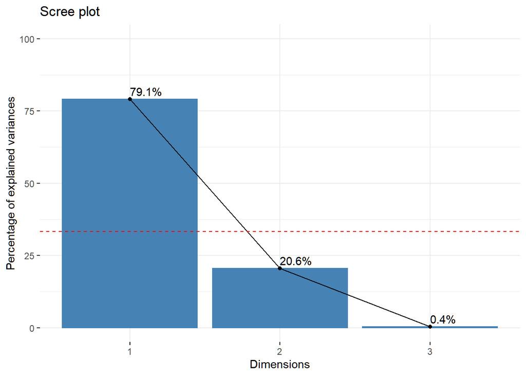

```r
fviz_screeplot(res.ca, addlabels = TRUE, ylim = c(0, 100)) +
  geom_hline(yintercept = max((1/(nrow(dt)-1)) * 100, (1/(ncol(dt)-1)) * 100), linetype = 2, color = "red")
```

Cualquier eje incluido por encima de la linea roja debe ser considerado como importante en la solucion de la interpretacion de la data.

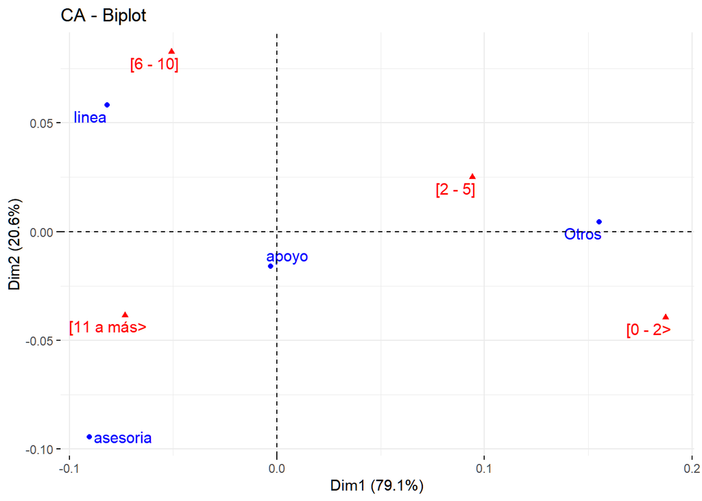

```r
fviz_ca_biplot(res.ca, repel = TRUE)
```

Los de apoyo y asesoria se acercan a los que trabajan de 11 años a mas.

Los de otros organos se acercan a los que trabajan hasta 5 años en el estado.

## Grafico de la variable " Organo de pertenencia"

```r
row <- get_ca_row(res.ca)
row
```

```
## Correspondence Analysis - Results for rows
##  ===================================================
##   Name       Description
## 1 "$coord"   "Coordinates for the rows"
## 2 "$cos2"    "Cos2 for the rows"
## 3 "$contrib" "contributions of the rows"
## 4 "$inertia" "Inertia of the rows"
```

### Coordenadas

```r
row$coord
```

```
##                 Dim 1        Dim 2        Dim 3
## apoyo    -0.003096458 -0.015852635 -0.009531752
## asesoria -0.090465190 -0.094298196  0.007130461
## linea    -0.081929564  0.058263620  0.002780771
## Otros     0.155399973  0.004363316  0.003970700
```

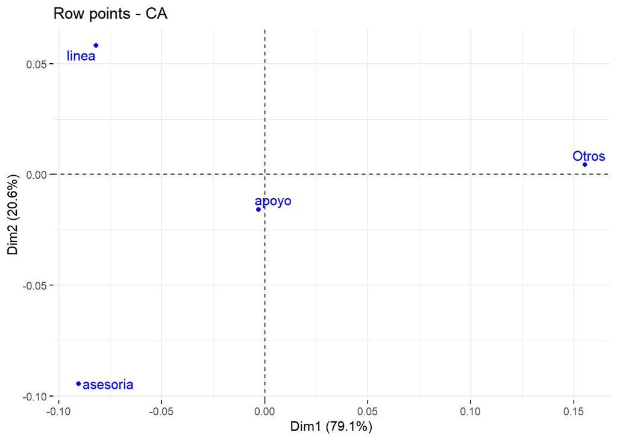

```r
fviz_ca_row(res.ca, repel = TRUE)
```

No se aprecian perfiles similares entre las categorias de organos de gobierno.

La categoria asesoria esta correlacionado negativamente.

Las categorias asesoria y otros estan bien representados en el mapa.

### Calidad de la representacion

```r
row$cos2
```

```
##               Dim 1        Dim 2        Dim 3
## apoyo    0.02725827 0.7144483056 0.2582934241
## asesoria 0.47784069 0.5191906843 0.0029686252
## linea    0.66362458 0.3356109337 0.0007644896
## Otros    0.99856082 0.0007872379 0.0006519388
```

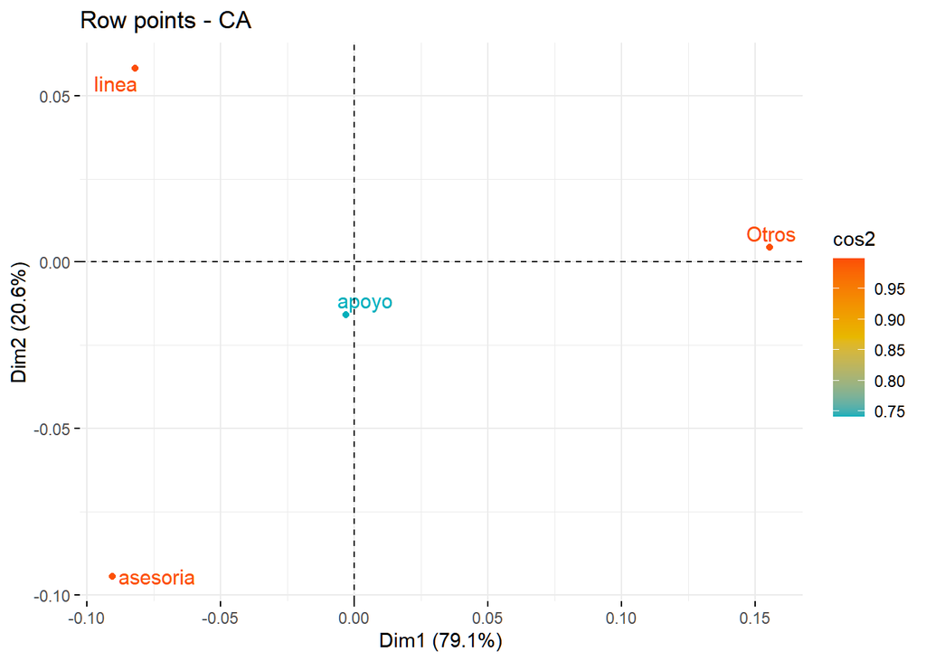

```r
fviz_ca_row(res.ca, col.row = "cos2", gradient.cols = c("#00AFBB", "#E7B800", "#FC4E07"), repel = TRUE)
```

cos2 de las categorias en todas las dimensiones

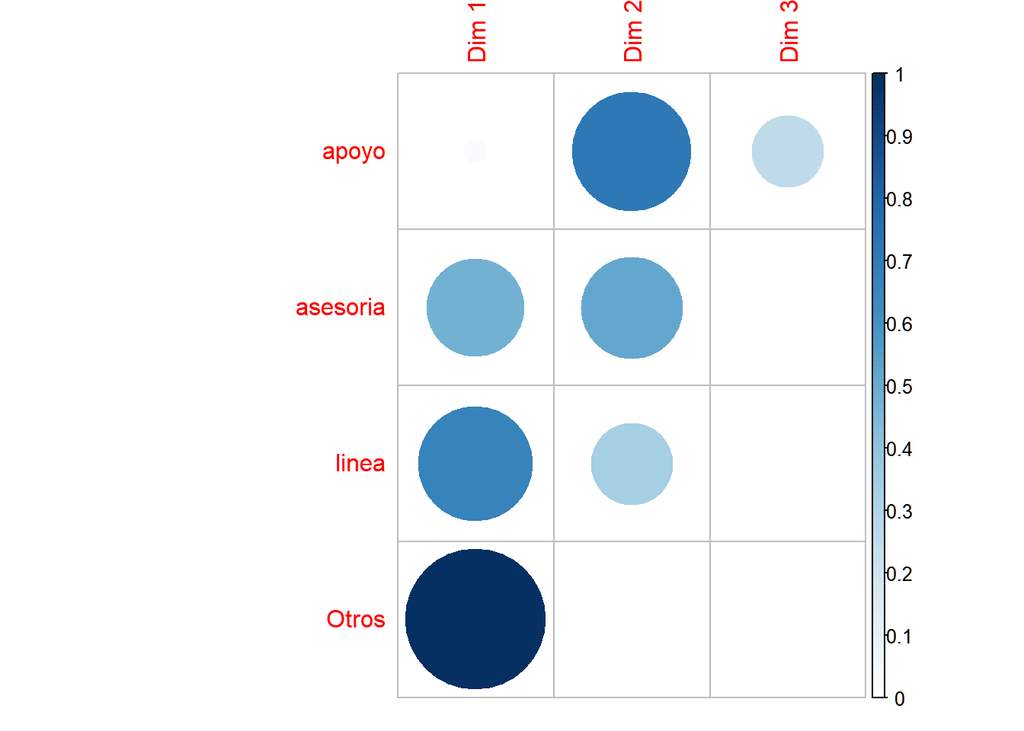

```r
corrplot(row$cos2, is.corr = FALSE)
```

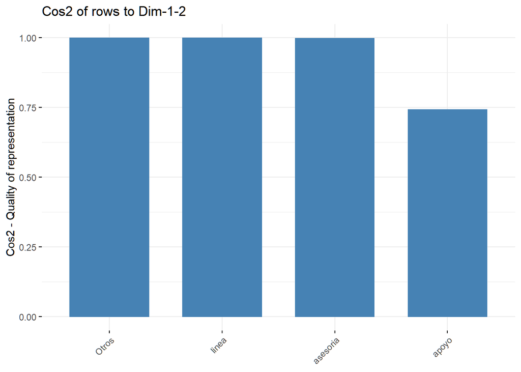

```r
fviz_cos2(res.ca, choice = "row", axes = 1:2)
```

Todas las categorias estan bien representadas en las dos dimensiones.

### Contribuciones

```r
row$contrib
```

```
##                Dim 1      Dim 2     Dim 3
## apoyo     0.03123355  3.1504089 66.628071
## asesoria 12.96615516 54.2160704 18.134446
## linea    21.80443409 42.4357145  5.654768
## Otros    65.19817720  0.1978062  9.582716
```

Segun parece la categoria apoyo es la menos importante en explicar la variabilidad.

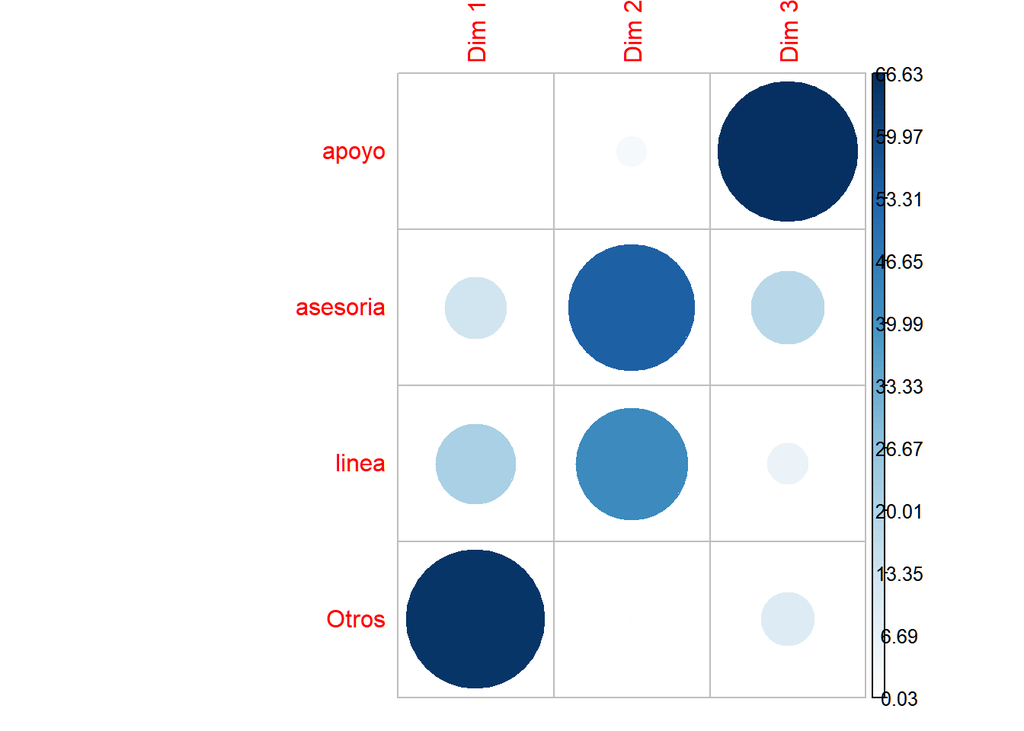

```r
corrplot(row$contrib, is.corr = FALSE)
```

contribucion a la dimension 1

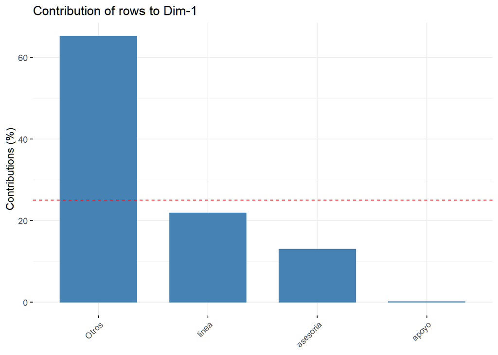

```r
fviz_contrib(res.ca, choice = "row", axes = 1)
```

contribucion a la dimension 2

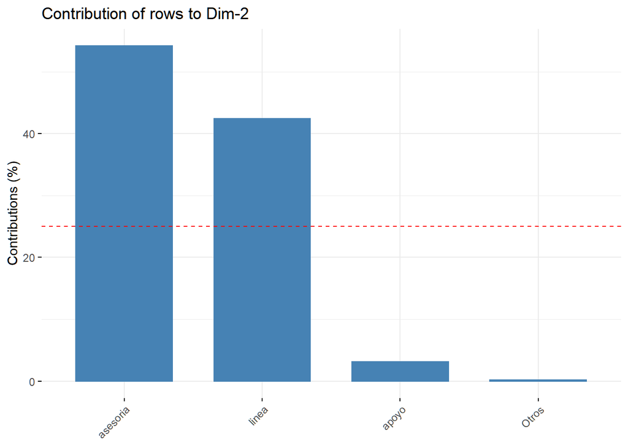

```r
fviz_contrib(res.ca, choice = "row", axes = 2)
```

contribucion a la dimension 1 y 2

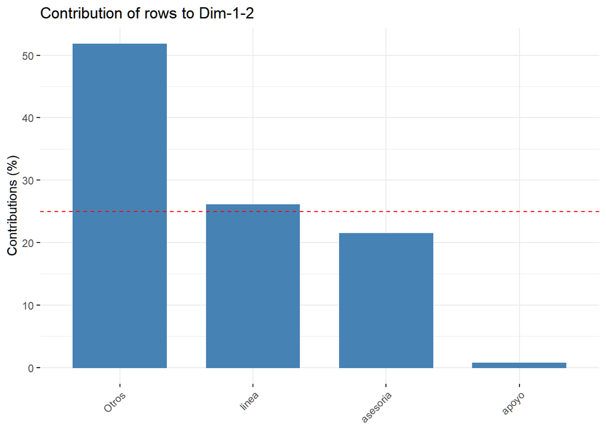

```r
fviz_contrib(res.ca, choice = "row", axes = 1:2)
```

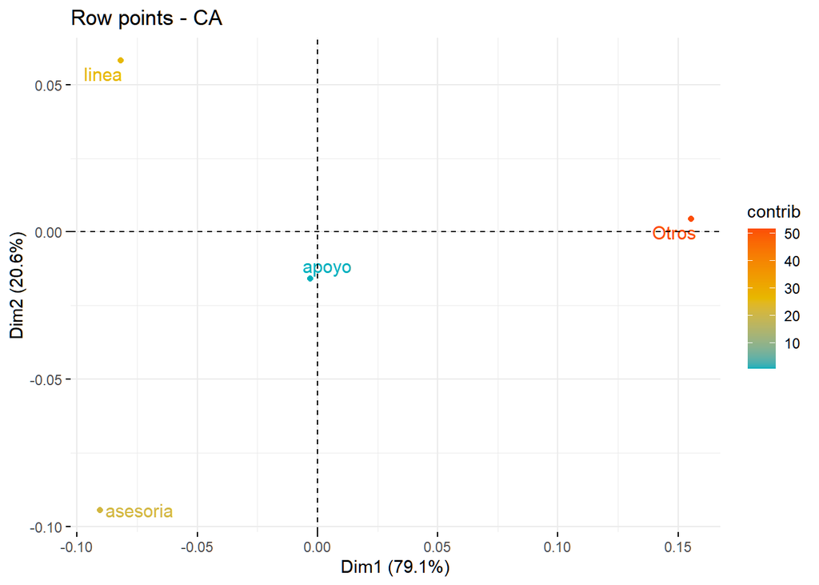

```r
fviz_ca_row(res.ca, col.row = "contrib", gradient.cols = c("#00AFBB", "#E7B800", "#FC4E07"),
repel = TRUE)
```

Se ve una oposicion entre las categorias otros, linea y asesoria.

## Grafico de la variable " Años trabajando para el estado"

### Resultados

```r
col <- get_ca_col(res.ca)
col
```

```
## Correspondence Analysis - Results for columns
##  ===================================================
##   Name       Description
## 1 "$coord"   "Coordinates for the columns"
## 2 "$cos2"    "Cos2 for the columns"
## 3 "$contrib" "contributions of the columns"
## 4 "$inertia" "Inertia of the columns"
```

coordenadas, calidad y representacion

```r
col$coord
```

```
##                  Dim 1       Dim 2         Dim 3
## [0 - 2>     0.18718460 -0.03936301  0.0102661383
## [2 - 5]     0.09407657  0.02501424 -0.0099899519
## [6 - 10]   -0.05087172  0.08279034  0.0055365813
## [11 a más> -0.07332433 -0.03847568 -0.0005932051
```

```r
col$cos2
```

```
##                Dim 1      Dim 2        Dim 3
## [0 - 2>    0.9549003 0.04222741 0.0028723147
## [2 - 5]    0.9242358 0.06534233 0.0104218930
## [6 - 10]   0.2731953 0.72356872 0.0032359653
## [11 a más> 0.7840616 0.21588707 0.0000513173
```

```r
col$contrib
```

```
##                Dim 1     Dim 2      Dim 3
## [0 - 2>    47.351798  8.058346 32.0650045
## [2 - 5]    20.585547  5.600764 52.2573128
## [6 - 10]    5.733882 58.442437 15.2897423
## [11 a más> 26.328773 27.898453  0.3879404
```

### Calidad

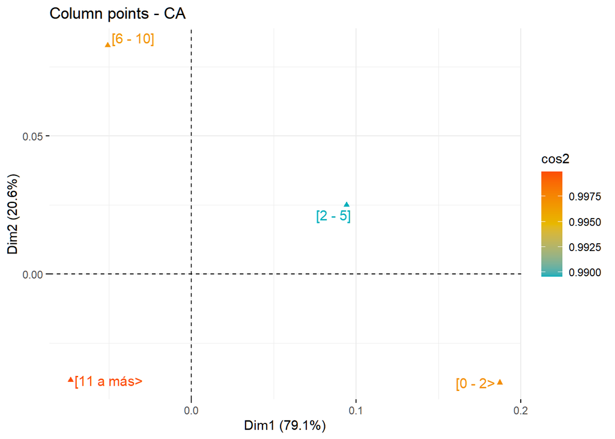

```r
fviz_ca_col(res.ca, col.col = "cos2", gradient.cols = c("#00AFBB", "#E7B800", "#FC4E07"), repel = TRUE)
```

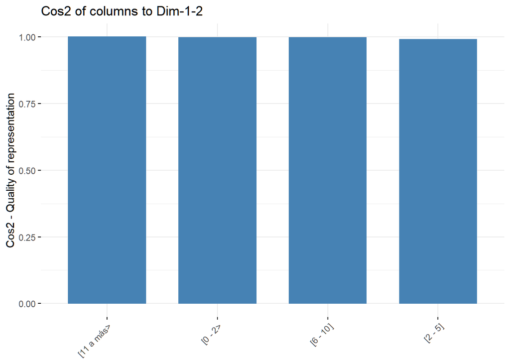

```r
fviz_cos2(res.ca, choice = "col", axes = 1:2)
```

Todas las categorias estan bien representadas en el mapa de factores.

### Contribucion

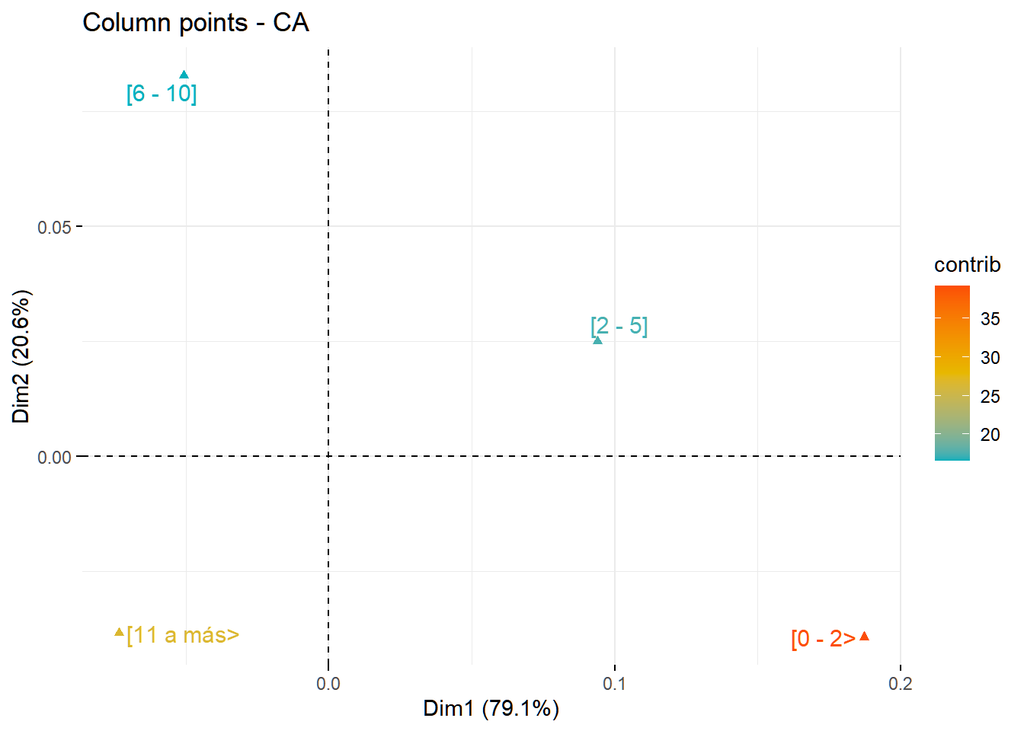

```r
fviz_ca_col(res.ca, col.col = "contrib", gradient.cols = c("#00AFBB", "#E7B800", "#FC4E07"), repel = TRUE)
```

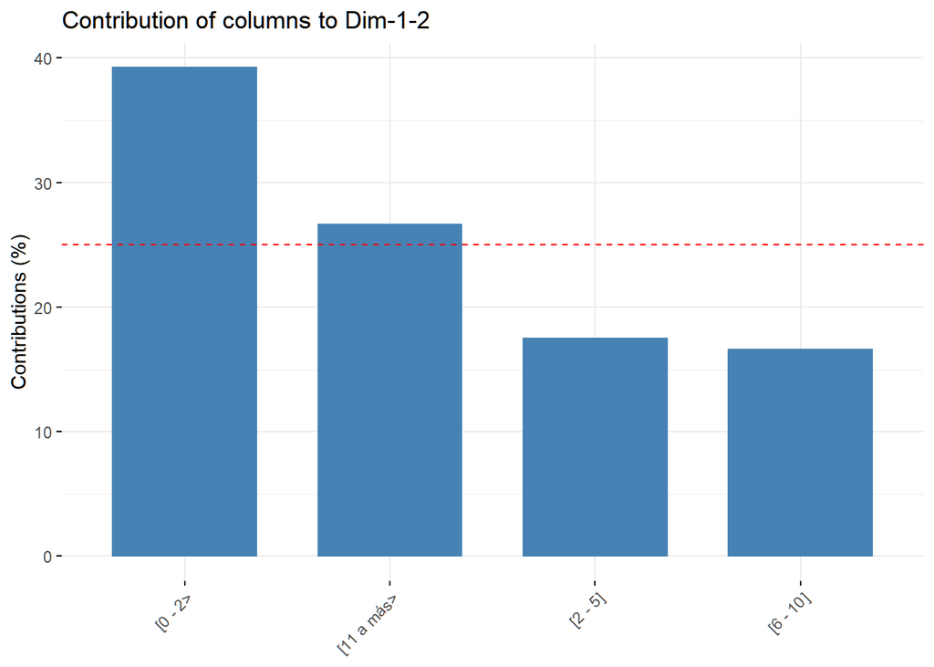

```r
fviz_contrib(res.ca, choice = "col", axes = 1:2)
```

## Grafico biplot

### Biplot simetrico

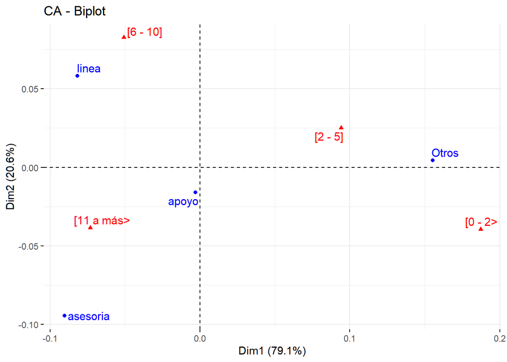

```r
fviz_ca_biplot(res.ca, repel = TRUE)
```

### Biplot asimetrico

Sirven para interpretar las distancias entre los atributos de las variables.

En este caso, las categorias de la segunda variable se representan en el espacio de la primera variable.

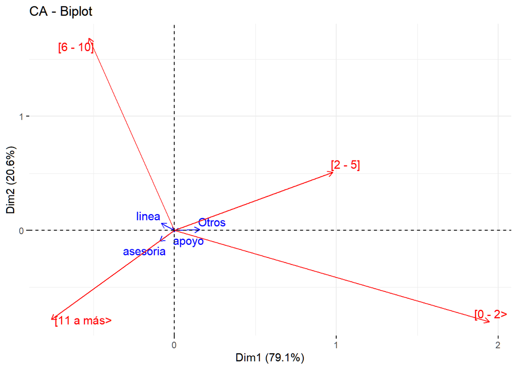

```r
fviz_ca_biplot(res.ca, map = "rowprincipal", arrow = c(TRUE, TRUE), repel = TRUE)
```

Existe una fuerte asociacion entre organo de asesoria y los que trabajan de 11 años a mas.

### Contribucion biplot

Contribucion de las filas en los ejes

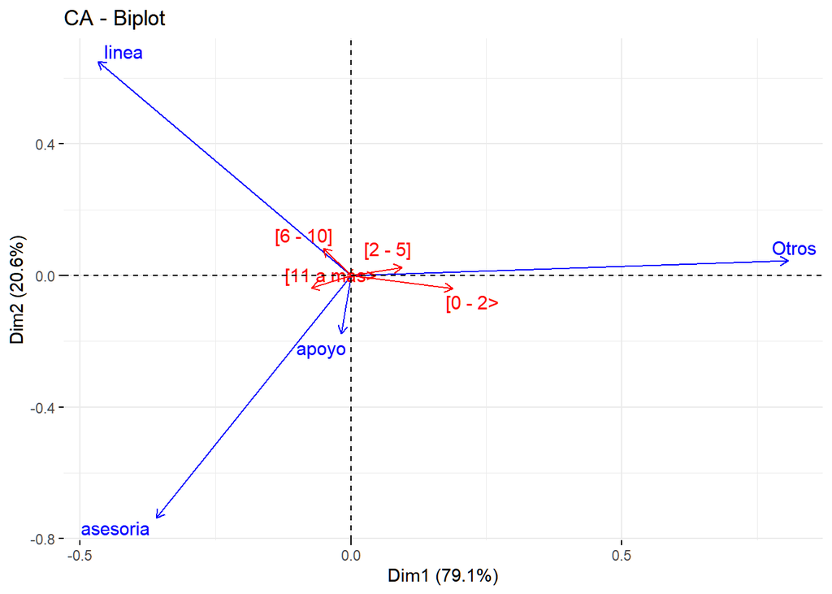

```r
fviz_ca_biplot(res.ca, map = "colgreen", arrow = c(TRUE, TRUE), repel = TRUE)
```

La categoria “otros” tiene una importante contribucion al polo positivo de la primera dimension.

## Descripcion de las dimensiones

Identificaremos las categorias que esten mas asociadas a las dimensiones.

```r
res.desc <- dimdesc(res.ca, axes = c(1, 2))
res.desc
```

```
## $`Dim 1`
## $`Dim 1`$row
##                 coord
## asesoria -0.090465190
## linea    -0.081929564
## apoyo    -0.003096458
## Otros     0.155399973
##
## $`Dim 1`$col
##                  coord
## [11 a más> -0.07332433
## [6 - 10]   -0.05087172
## [2 - 5]     0.09407657
## [0 - 2>     0.18718460
##
##
## $`Dim 2`
## $`Dim 2`$row
##                 coord
## asesoria -0.094298196
## apoyo    -0.015852635
## Otros     0.004363316
## linea     0.058263620
##
## $`Dim 2`$col
##                  coord
## [0 - 2>    -0.03936301
## [11 a más> -0.03847568
## [2 - 5]     0.02501424
## [6 - 10]    0.08279034
```

Descripcion de la dimension 1 por categorias de la primera variable.

```r
res.desc[[1]]$row
```

```
##                 coord
## asesoria -0.090465190
## linea    -0.081929564
## apoyo    -0.003096458
## Otros     0.155399973
```

Descripcion de la dimension 1 por categorias de la segunda variable.

```r
res.desc[[1]]$col
```

```
##                  coord
## [11 a más> -0.07332433
## [6 - 10]   -0.05087172
## [2 - 5]     0.09407657
## [0 - 2>     0.18718460
```

Descripcion de la dimension 2 por categorias de la primera variable.

```r
res.desc[[2]]$row
```

```
##                 coord
## asesoria -0.094298196
## apoyo    -0.015852635
## Otros     0.004363316
## linea     0.058263620
```

Descripcion de la dimension 2 por categorias de la segunda variable.

```r
res.desc[[2]]$col
```

```
##                  coord
## [0 - 2>    -0.03936301
## [11 a más> -0.03847568
## [2 - 5]     0.02501424
## [6 - 10]    0.08279034
```

## Analisis con elementos complementarios

Debido a que las categorias “otros” y “[0 - 2]” tienen valores altos en sus coordenadas y contribuciones, se les va ha tomar como outliers y por tanto se les tratara como categorias complementarias.

```r
res2.ca <- CA(dt, row.sup = 4, col.sup = 1, graph = FALSE)
```

## Biplot de filas y columnas

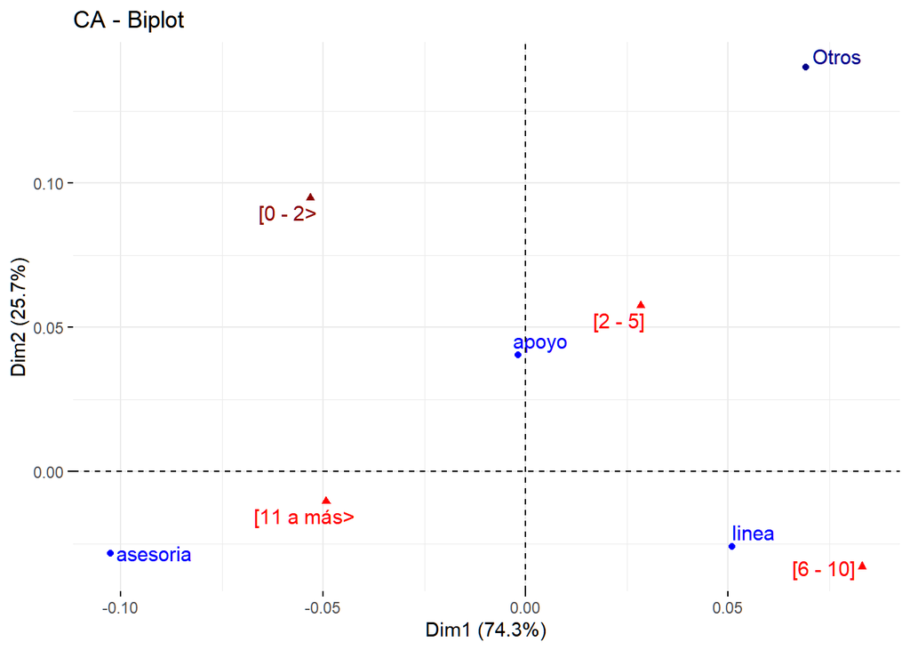

```r
fviz_ca_biplot(res2.ca, repel = TRUE)
```

## Categoria “otros”

Predecimos los resultados de la categoria “otros”.

```r
res2.ca$row.sup
```

```
## $coord
##            Dim 1     Dim 2
## Otros 0.06914244 0.1402821
##
## $cos2
##           Dim 1     Dim 2
## Otros 0.1954509 0.8045491
```

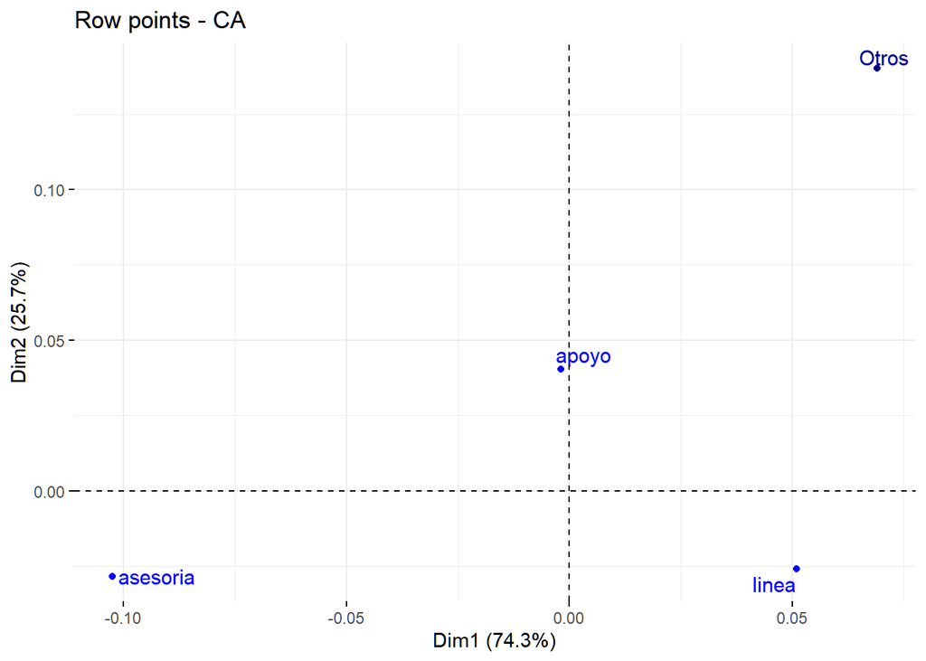

```r
fviz_ca_row(res2.ca, repel = TRUE)
```

## Categoria “0 a 2 años”

```r
res2.ca$col.sup
```

```
## $coord
##               Dim 1      Dim 2
## [0 - 2> -0.05329665 0.09485656
##
## $cos2
##             Dim 1     Dim 2
## [0 - 2> 0.2399444 0.7600556
```

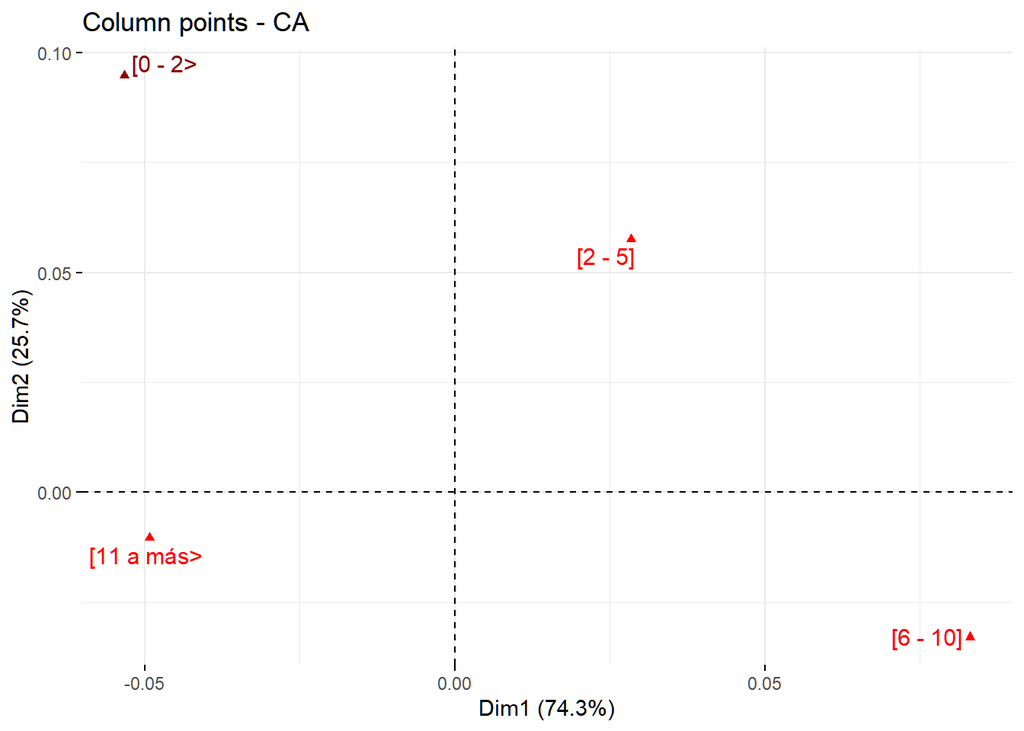

```r
fviz_ca_col(res2.ca, repel = TRUE)
```

## Biplots asimetricos con categorias complementarias

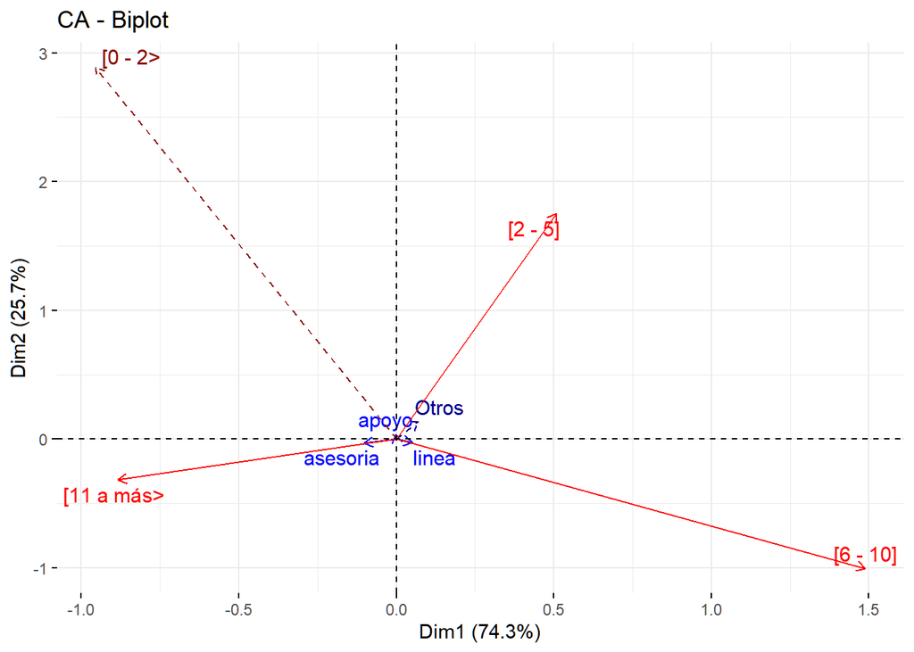

```r
fviz_ca_biplot(res2.ca, map = "rowprincipal", arrow = c(TRUE, TRUE), repel = TRUE)
```

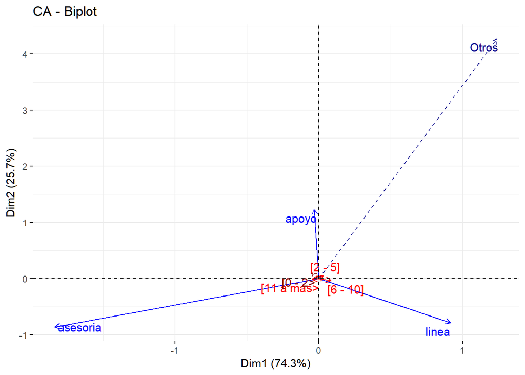

```r
fviz_ca_biplot(res2.ca, map = "colprincipal", arrow = c(TRUE, TRUE), repel = TRUE)
```

## Concluciones

Se pueden encontrar patrones entre los que trabajan de “6 a 10 años” con el organo de “linea”.

Se pueden encontrar patrones entre los que trabajan de “2 a 5 años” en el estado con los de “otros” organos.

Se pueden encontrar patrones entre los que trabajan de 11 años a mas y la categoria “asesoria”.